# Additional Answers for Water Quality Section

Christian Nilsen

5/29/2020

1.) For each landscape predictor, how did you assign a landscape predictor value to each outfall/COC value?

```
We obtained shapefiles from the reporting agencies where available. In some cases we delineated them ourselves from
reports submitted by agencies. We then used Earth Engine to calculate the mean value for the watershed. We used a 30-meter scale to do so.
```

See this map for watershed boundaries and some predictors: https://stormwaterheatmap.users.earthengine.app/view/predictors

2.) Section 4.3.2, controlling for multicolinearity: is the final list of candidate landscape predictors the same for all COC’s?

```
Yes, although the VIF was slightly different.
**Note, we noticed that this step removed some valid predictors for certain models. We decided to perform this step after model selection as a check in order to keep valid predictors in the analysis**
```

3.) I’d like to take a look at the landscape predictor values and your cleaned-up COC data. Do you have a csv file that includes the suite of landscape predictor values (minus those removed b/c of colinearity) that you tested against COC’s for each outfall?

```
File available here: https://github.com/stormwaterheatmap/stormwaterheatmap.github.io/raw/master/docs/data/s8data.wPredictors.csv

Code used to generate is below.
```

```r
all.S8.data <- read.csv("data/S8_data.csv",
                        stringsAsFactors = FALSE )

#filter out rejected data
all.S8.data <- (filter(all.S8.data,!result_data_qualifier %in% 'REJ'))

#filter out replicates
all.S8.data <- (filter(all.S8.data,!sample_replicate_flag %in% 'Y'))

#change nondetect warnings to detects
warnings <- all.S8.data$nondetect_flag == "WARNING"
all.S8.data$nondetect_flag[warnings] <- FALSE

#Change NA to detect
all.S8.data$nondetect_flag[is.na(all.S8.data$nondetect_flag)] <- FALSE

#Change season to factor
all.S8.data$season <- as.factor(all.S8.data$season)
#Select Parameters
params <- c('Zinc - Water - Total',
 'Copper - Water - Total',
 'Nitrite-Nitrate - Water - Dissolved',
 'Lead - Water - Total',
 'Total Phosphorus - Water - Total',
 'Total Suspended Solids - Water - Total',
 'Total Phthalate - Water - Total',
'Total PAH - Water - Total',
'CPAH - Water - Total',
'HPAH - Water - Total'

)

#save a list of all the parameters in case we want to use mor.
params.all <- data.frame(unique(all.S8.data$parameter))
all.S8.data <- (filter(all.S8.data,parameter %in% params))
s8data <- all.S8.data %>%
  dplyr::select(
    study_name,
    location_id,parameter,
    type,
    season,
    new_result_value,
    nondetect_flag,
    study_id,
    access_id,
    field_collection_end_date,
    field_collection_start_date,
    type)


#rename some columns
colnames(s8data)[colnames(s8data) == "location_id"] <- "Location"
colnames(s8data)[colnames(s8data) == "new_result_value"] <-
  "concentration"
s8data$nondetect_flag <- as.logical(s8data$nondetect_flag)
s8data$concentration <- as.numeric(s8data$concentration)
s8data$SiteID <- as.character(as.numeric(as.factor(s8data$Location))+10)

outlierParams <- c("Total Suspended Solids - Water - Total", "Total Phosphorus - Water - Total", "Nitrite-Nitrate - Water - Dissolved")

#This removes the highest values
outlierVals <-
  top_n(group_by(s8data[which(s8data$parameter %in% outlierParams), ], parameter), 1, concentration)$concentration

s8data <- s8data %>%
  group_by(parameter) %>%
  slice(which(!(
    parameter %in% outlierParams & concentration %in% outlierVals
  )))
#Spatial predcitors have been extracted and saved as a csv file.

spatial_data <- read_csv("data/spatialPredictors_526.csv")

spatial_data <- dplyr::select(spatial_data, -c(`system:index`,.geo))
#merge spatial predictors with monitoring data
s8data.wPredictors <<- merge(s8data, spatial_data)#%>%
kable(head(s8data.wPredictors))
```

| Location | study_name | parameter | type | season | concentration | nondetect_flag | study_id | access_id | field_collection_end_date | field_collection_start_date | SiteID | COM | RES | constant | depSplusN | impervious | logPopulation | logTraffic | nighttime_lights | pm25 | population | roadDensity | traffic |
| --- | --- | --- | --- | --- | --- | --- | --- | --- | --- | --- | --- | --- | --- | --- | --- | --- | --- | --- | --- | --- | --- | --- | --- |
| KICCOMS8D_OUT | King County Phase I Municipal Stormwater Permit | CPAH - Water - Total | COM | 4 | 0.0094 | TRUE | WAR044501_S8D | 103419 | NA | 10/14/2009 | 12 | 0.2160525 | -0.6717387 | 0.0875598 | 0.9026524 | -0.0393797 | -0.5635381 | -0.0024556 | -1.679003 | -0.750305 | -0.4521246 | 0.0328475 | -0.2234526 |
| KICCOMS8D_OUT | King County Phase I Municipal Stormwater Permit | Zinc - Water - Total | COM | 1 | 46.7000 | FALSE | WAR044501_S8D | 17555 | 2/25/2013 | 2/25/2013 | 12 | 0.2160525 | -0.6717387 | 0.0875598 | 0.9026524 | -0.0393797 | -0.5635381 | -0.0024556 | -1.679003 | -0.750305 | -0.4521246 | 0.0328475 | -0.2234526 |
| KICCOMS8D_OUT | King County Phase I Municipal Stormwater Permit | HPAH - Water - Total | COM | 4 | 0.1396 | FALSE | WAR044501_S8D | 102200 | NA | 11/5/2009 | 12 | 0.2160525 | -0.6717387 | 0.0875598 | 0.9026524 | -0.0393797 | -0.5635381 | -0.0024556 | -1.679003 | -0.750305 | -0.4521246 | 0.0328475 | -0.2234526 |
| KICCOMS8D_OUT | King County Phase I Municipal Stormwater Permit | HPAH - Water - Total | COM | 1 | 0.3021 | FALSE | WAR044501_S8D | 102224 | NA | 2/12/2011 | 12 | 0.2160525 | -0.6717387 | 0.0875598 | 0.9026524 | -0.0393797 | -0.5635381 | -0.0024556 | -1.679003 | -0.750305 | -0.4521246 | 0.0328475 | -0.2234526 |
| KICCOMS8D_OUT | King County Phase I Municipal Stormwater Permit | Total PAH - Water - Total | COM | 4 | 0.1141 | FALSE | WAR044501_S8D | 100187 | NA | 12/13/2012 | 12 | 0.2160525 | -0.6717387 | 0.0875598 | 0.9026524 | -0.0393797 | -0.5635381 | -0.0024556 | -1.679003 | -0.750305 | -0.4521246 | 0.0328475 | -0.2234526 |
| KICCOMS8D_OUT | King County Phase I Municipal Stormwater Permit | Copper - Water - Total | COM | 1 | 39.1000 | FALSE | WAR044501_S8D | 19662 | 3/13/2013 | 3/13/2013 | 12 | 0.2160525 | -0.6717387 | 0.0875598 | 0.9026524 | -0.0393797 | -0.5635381 | -0.0024556 | -1.679003 | -0.750305 | -0.4521246 | 0.0328475 | -0.2234526 |

```r
write.csv(s8data.wPredictors,'s8data.wPredictors.csv')
```

4.) Have you done any correlation plots between transformed (or untransformed) COC’s, landscape predictors, and season? If you are using R, I like the function PerformanceAnalytics::chart.Correlation for this purpose. If you haven’t done any correlation plots but can send me the data, that is fine too.

```
See below
```

```r
library(PerformanceAnalytics)
corFun <- function(i){
  df.coc <- dplyr::filter(s8data.wPredictors,parameter == params[i])
return(chart.Correlation(cbind("log(Conc)" = log(df.coc$concentration),df.coc[,13:21],"road dens" = df.coc[,24]),title=params[i]))
}
```

```r
i=1
kable(params[i])
```

| x |
| --- |
| Zinc - Water - Total |

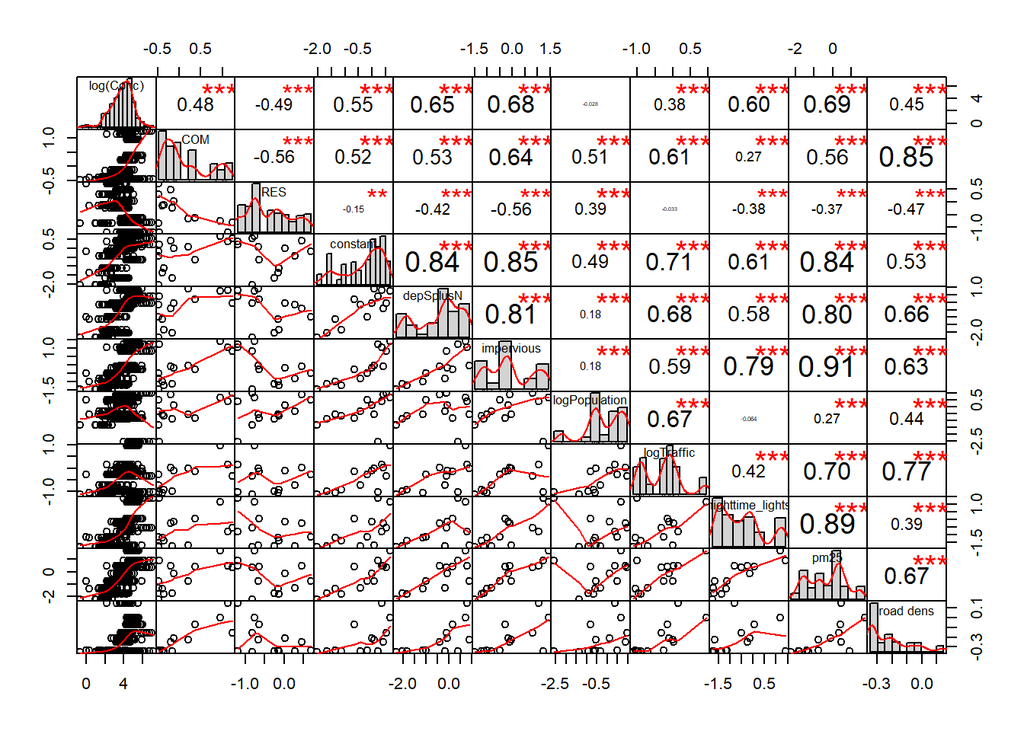

```r
corFun(i)
```

```r
i=i+1
kable(params[i])
```

| x |
| --- |
| Copper - Water - Total |

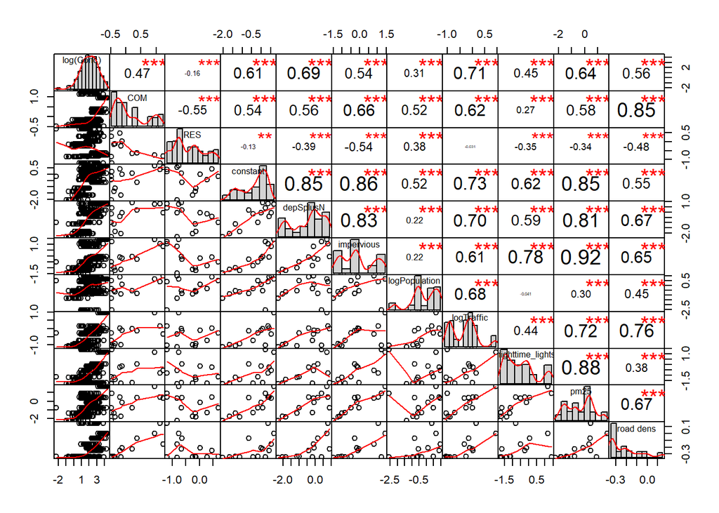

```r
corFun(i)
```

```r
i=i+1
kable(params[i])
```

| x |
| --- |
| Nitrite-Nitrate - Water - Dissolved |

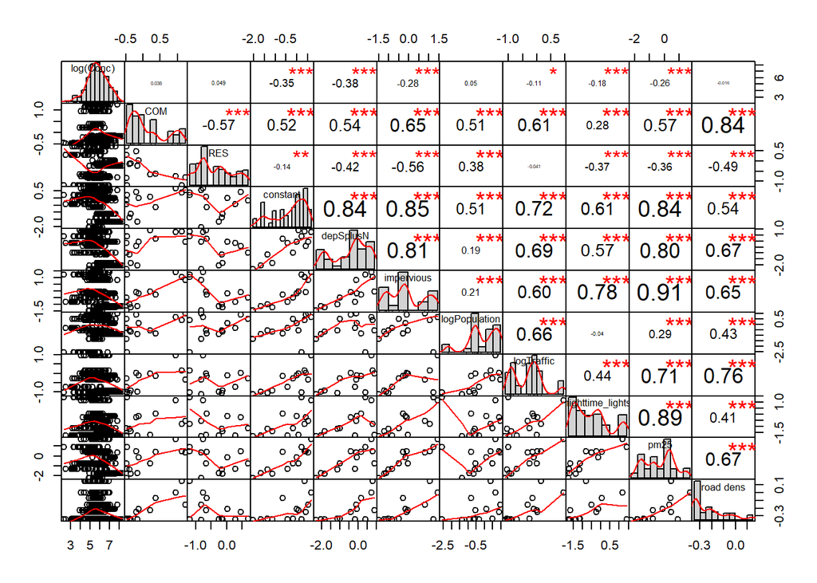

```r
corFun(i)
```

```r
i=i+1
kable(params[i])
```

| x |
| --- |
| Lead - Water - Total |

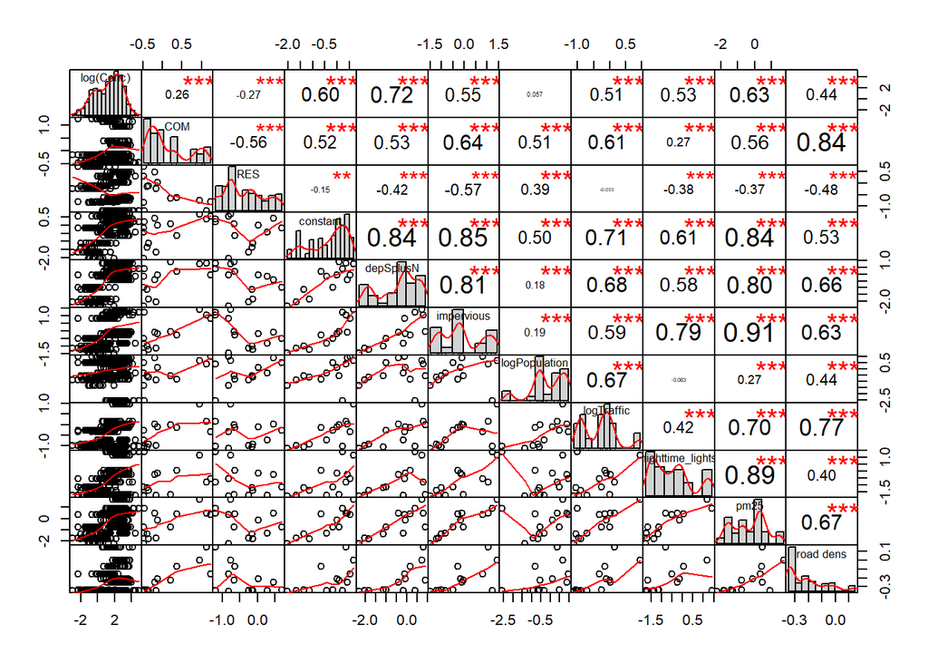

```r
corFun(i)
```

```r
i=i+1
kable(params[i])
```

| x |
| --- |
| Total Phosphorus - Water - Total |

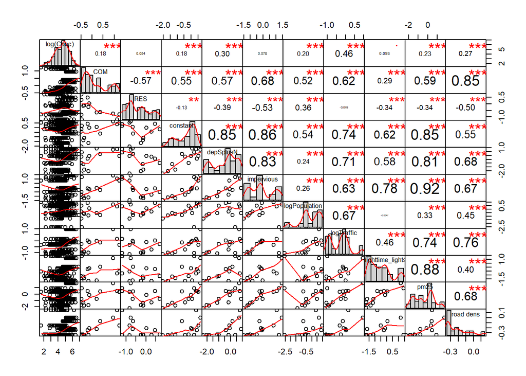

```r
corFun(i)
```

```r
i=i+1
kable(params[i])
```

| x |
| --- |
| Total Suspended Solids - Water - Total |

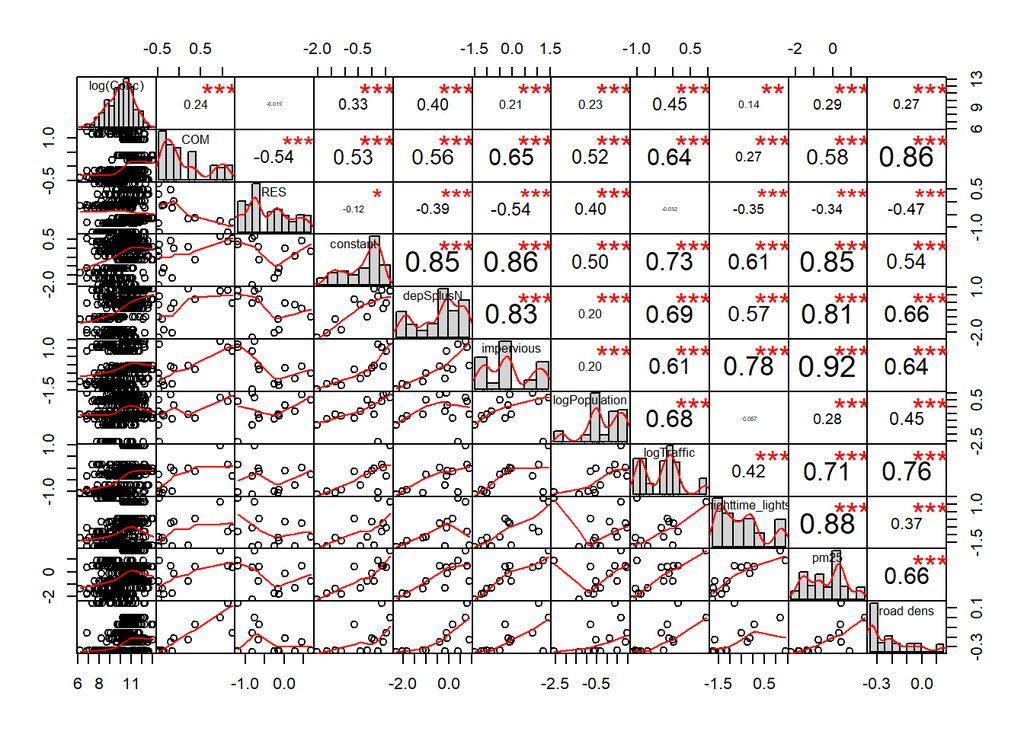

```r
corFun(i)
```

```r
i=i+1
kable(params[i])
```

| x |
| --- |
| Total Phthalate - Water - Total |

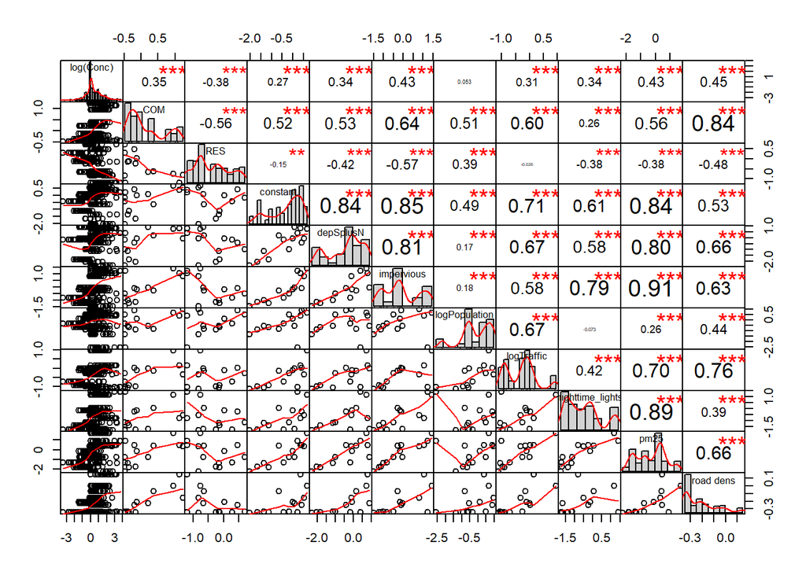

```r
corFun(i)
```

```r
i=i+1
kable(params[i])
```

| x |
| --- |
| Total PAH - Water - Total |

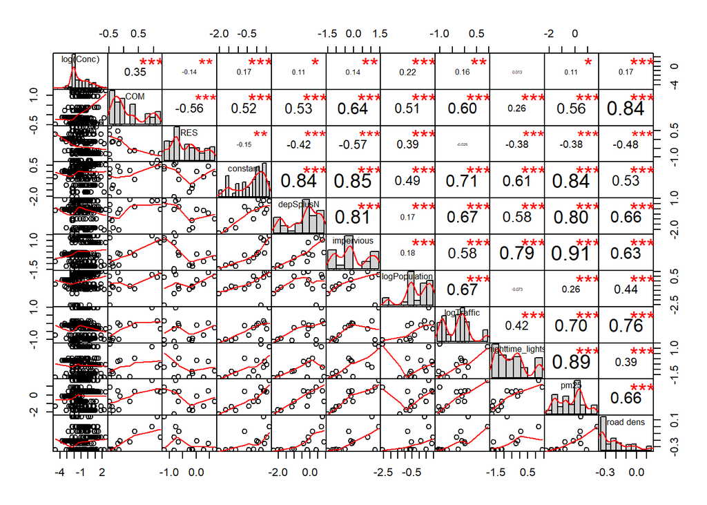

```r
corFun(i)
```

```r
i=i+1
kable(params[i])
```

| x |
| --- |
| CPAH - Water - Total |

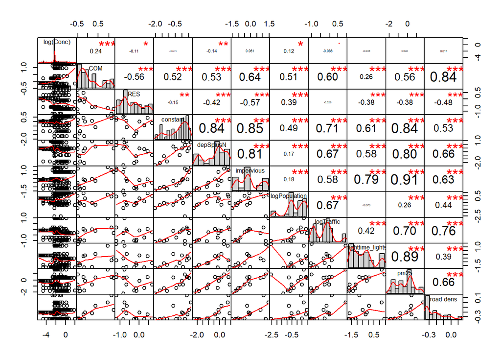

```r
corFun(i)
```

```r
i=i+1
kable(params[i])
```

| x |
| --- |
| HPAH - Water - Total |

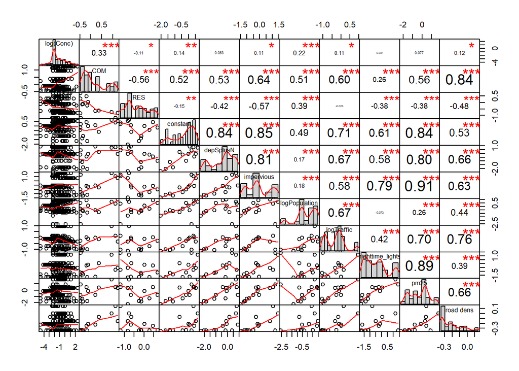

```r
corFun(i)
```

5.) In your mixed effects model, what is the equation that you used for the response variable (COC)? Is it the same for all COC’s? Within this response variable equation, how do you deal with the fact that there are multiple reporting limits for some COC’s?

6.) For each COC, I’d like to see AIC values for all landscape predictor values that were tested, prior to elimination of some. Also, please note that AIC values can only be used to compare models where the dependent variable is exactly the same across all models being compared. For example, you can not compare models with transformed vs untransformed data using AIC, without an intensive correction process.

7.) Can you please provide the equation used in: a.) a linear mixed effects model with no season effect (e.g. copper); and b.) a linear mixed effects model with a seasonal effect (e.g. total phosphorus)?